# Player Potential Modelling R Markdown Notebook

The statistical test for skewness produces a significantly low p-value which we can use to confirm that the data for the “dribbling” attribute is skewed. For kurtosis too, the p-value leads us to reject the null hypothesis. Using this, we can be sure that the “dribbling” attribute is not normally distributed.

```r

# Histogram, Density Plot and Q-Q plot of Player Defending

hist(temp_df$defending, xlab = “Player Defending”, main = “Histogram of Player Defending” ) ```

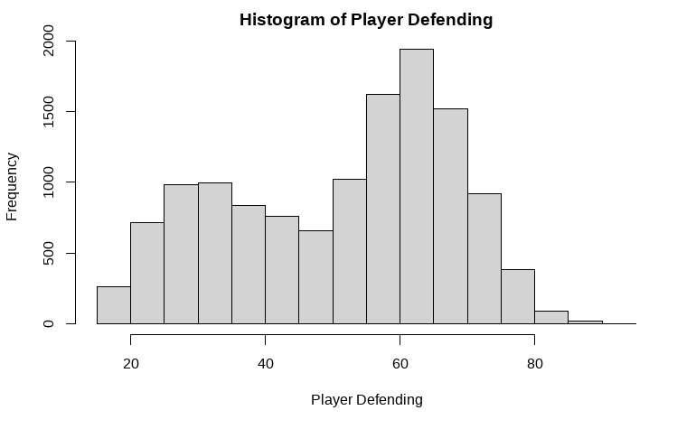

```r

defending_density <- density(temp_df$defending)

plot(defending_density, lwd= 2, col= “blue”) ```

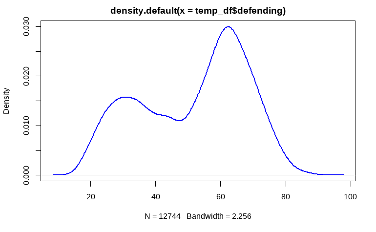

```r

qqnorm(temp_df$defending) qqline(temp_df$defending, col = “red”, lwd = 2) ```

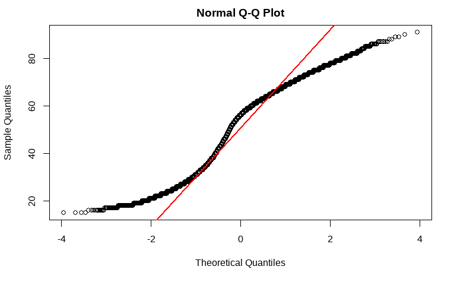

```r

# Tests of skewness

skewness(temp_df$defending) ```

`[1] -0.3322964`

`r agostino.test(temp_df$defending)`

```

D’Agostino skewness test

data: temp_df$defending skew = -0.3323, z = -14.9299, p-value < 2.2e-16 alternative hypothesis: data have a skewness ```

```r # Test of kurtosis

anscombe.test(temp_df$defending) ```

```

Anscombe-Glynn kurtosis test

data: temp_df$defending kurt = 1.9577, z = -60.6990, p-value < 2.2e-16 alternative hypothesis: kurtosis is not equal to 3 ```

For the test of skewness,we reject the null hypothesis and conclude that the data is skewed. However, for this same “defending” variable, the p-value of the test for kurtosis is significant enough for us to conclude that the data is not normally distributed.

```r

# Histogram, Density Plot and Q-Q plot of Player Physic Attribute

hist(temp_df$physic, xlab = “Player Physic Attribute”, main = “Histogram of Player Physic Attribute” ) ```

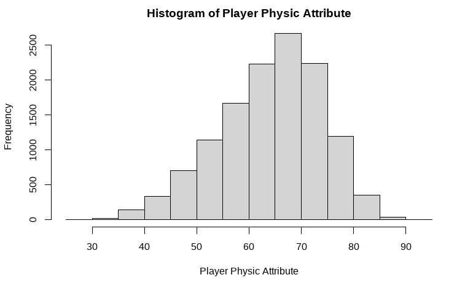

```r

physic_density <- density(temp_df$physic)

plot(physic_density, lwd= 2, col= “blue”) ```

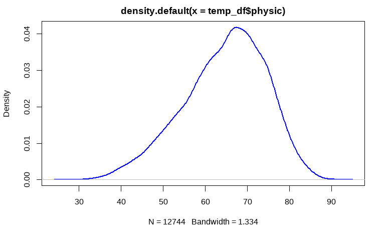

```r

qqnorm(temp_df$physic) qqline(temp_df$physic, col = “red”, lwd = 2) ```

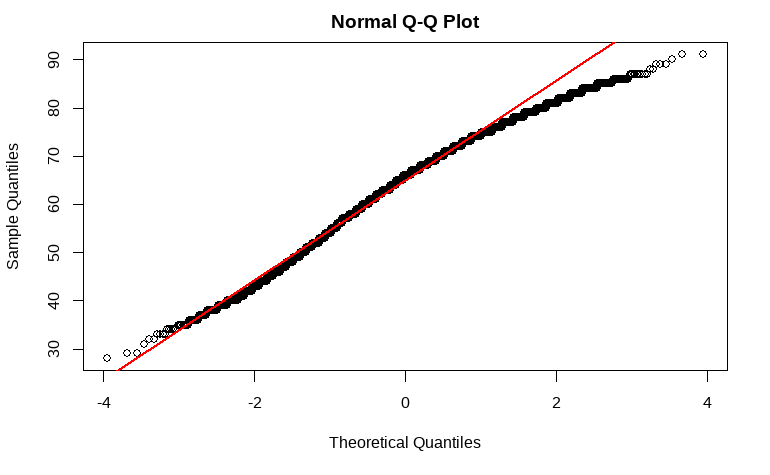

```r

# Tests of skewness

skewness(temp_df$physic) ```

`[1] -0.4401972`

`r agostino.test(temp_df$physic)`

```

D’Agostino skewness test

data: temp_df$physic skew = -0.4402, z = -19.4272, p-value < 2.2e-16 alternative hypothesis: data have a skewness ```

```r # Test of kurtosis

anscombe.test(temp_df$physic) ```

```

Anscombe-Glynn kurtosis test

data: temp_df$physic kurt = 2.8373, z = -4.0556, p-value = 5e-05 alternative hypothesis: kurtosis is not equal to 3 ```

For the “physic” attribute, we can see from the p-value of the test for skewness, that the data is skewed.

The kurtosis p-value also leads us to conclude that the data isn’t normally distributed

```r

# Histogram, Density Plot and Q-Q plot of Player Strength

hist(temp_df$power_strength, xlab = “Player Strength”, main = “Histogram of Player Strength” ) ```

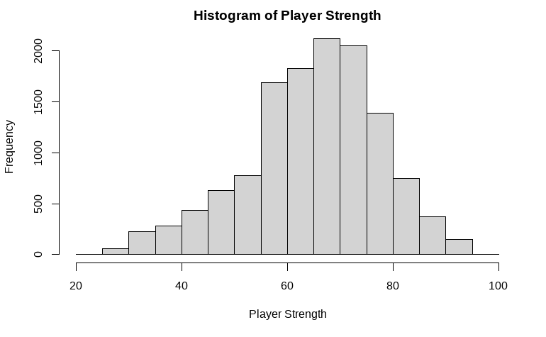

```r

strength_density <- density(temp_df$power_strength)

plot(strength_density, lwd= 2, col= “blue”) ```

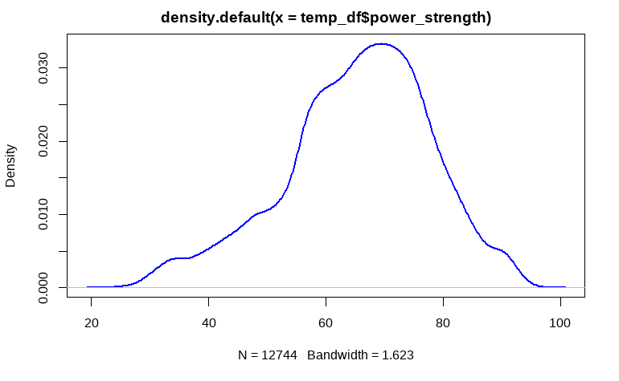

```r

qqnorm(temp_df$power_strength) qqline(temp_df$power_strength, col = “red”, lwd = 2) ```

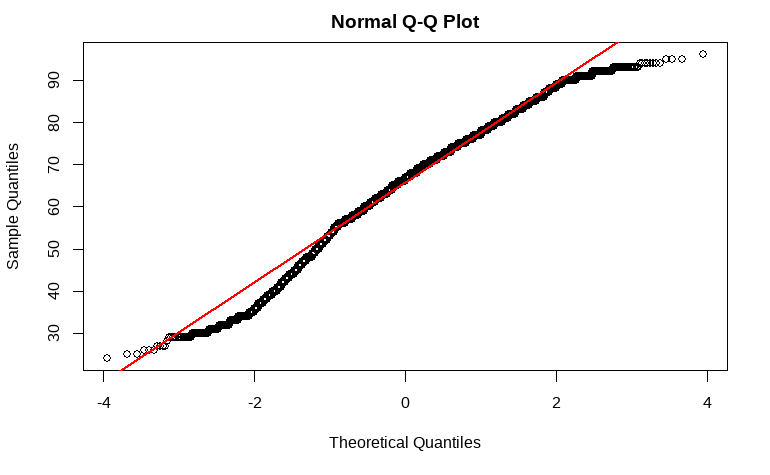

```r

# Tests of skewness

skewness(temp_df$power_strength) ```

`[1] -0.452835`

`r agostino.test(temp_df$power_strength)`

```

D’Agostino skewness test

data: temp_df$power_strength skew = -0.45284, z = -19.93866, p-value < 2.2e-16 alternative hypothesis: data have a skewness ```

```r # Test of kurtosis

anscombe.test(temp_df$power_strength) ```

```

Anscombe-Glynn kurtosis test

data: temp_df$power_strength kurt = 3.0463, z = 1.0765, p-value = 0.2817 alternative hypothesis: kurtosis is not equal to 3 ```

```r # Histogram, Density Plot and Q-Q plot of Player Long shots

hist(temp_df$power_long_shots, xlab = “Player Long shots”, main = “Histogram of Player Long shots” ) ```

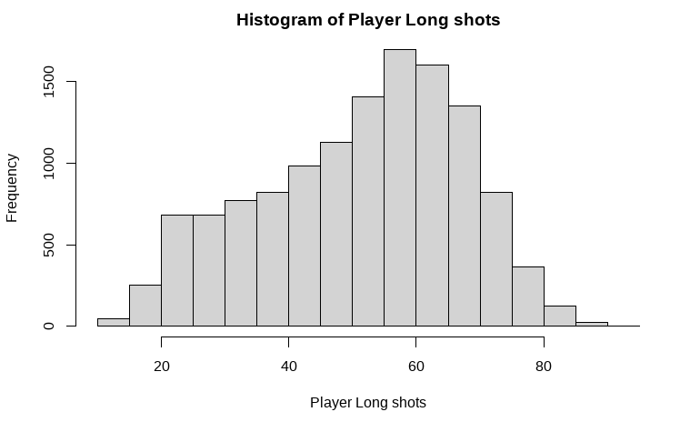

```r

long_shots_density <- density(temp_df$power_long_shots)

plot(long_shots_density, lwd= 2, col= “blue”) ```

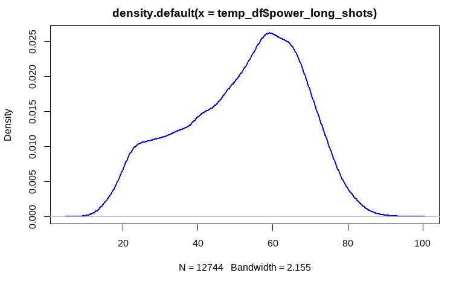

```r

qqnorm(temp_df$power_long_shots) qqline(temp_df$power_long_shots, col = “red”, lwd = 2) ```

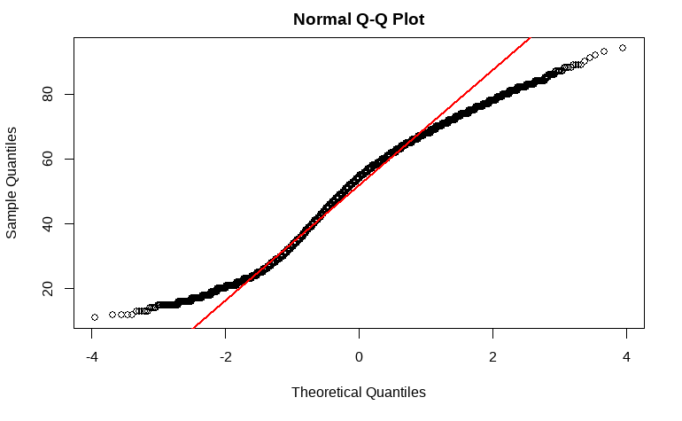

```r

# Tests of skewness

skewness(temp_df$power_long_shots) ```

`[1] -0.3404095`

`r agostino.test(temp_df$power_long_shots)`

```

D’Agostino skewness test

data: temp_df$power_long_shots skew = -0.34041, z = -15.27584, p-value < 2.2e-16 alternative hypothesis: data have a skewness ```

```r # Test of kurtosis

anscombe.test(temp_df$power_long_shots) ```

```

Anscombe-Glynn kurtosis test

data: temp_df$power_long_shots kurt = 2.2811, z = -27.1108, p-value < 2.2e-16 alternative hypothesis: kurtosis is not equal to 3 ```

The diagnostic tests of skewness and kurtosis are significantly small enough for “power_long_shots” that we can conclude that the data is both skewed and not normally distributed. The Q-Q plot also shows that it is not normally distributed.

## Boxplots

In the next section, I would check to see if there is any relationship between the numerical variables and the categorical variables.

# By Preferred Foot

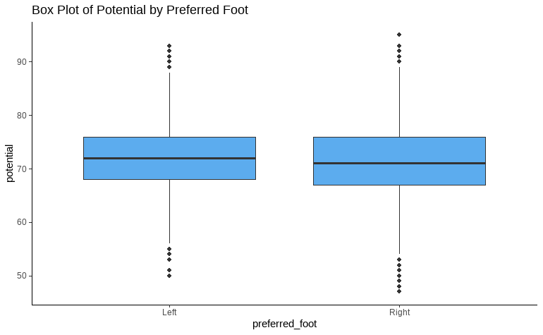

```r
ggplot(temp_df, aes(x=preferred_foot, y=potential)) +
  geom_boxplot(fill="steelblue2") +
  theme_classic() +
  labs(title="Box Plot of Potential by Preferred Foot")
```

We can see from the above diagram that the player’s preferred foot doesn’t seem to have any significant effect on their potential.

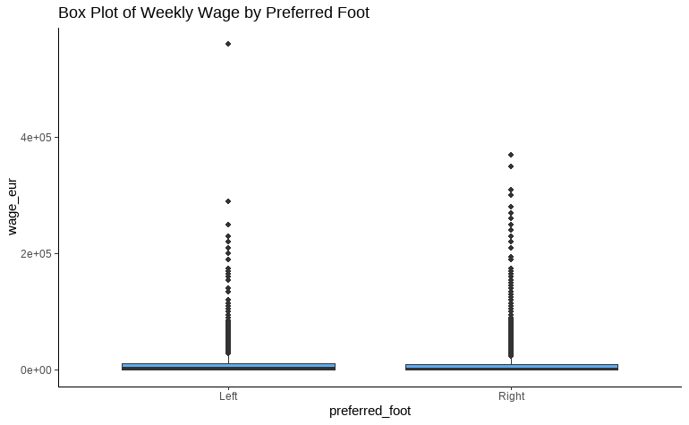

```r
ggplot(temp_df, aes(x=preferred_foot, y=wage_eur)) +
  geom_boxplot(fill="steelblue2") +
  theme_classic() +
  labs(title="Box Plot of Weekly Wage by Preferred Foot")
```

From the above plot, it can be observed that preferred foot does not have any significant effect on player wages.

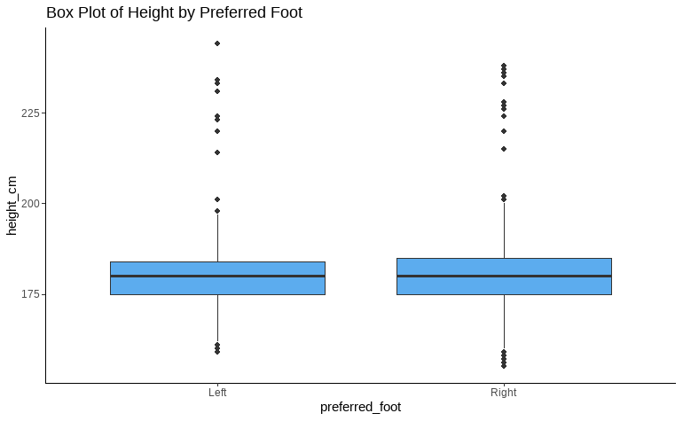

```r
ggplot(temp_df, aes(x=preferred_foot, y=height_cm)) +
  geom_boxplot(fill="steelblue2") +
  theme_classic() +
  labs(title="Box Plot of Height by Preferred Foot")
```

Preferred foot does not have a significant effect on the height of a player, from the above plot.

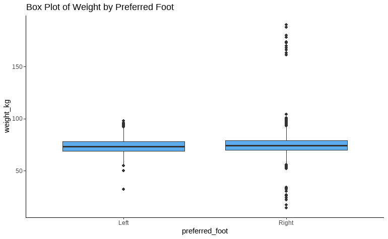

```r
ggplot(temp_df, aes(x=preferred_foot, y=weight_kg)) +
  geom_boxplot(fill="steelblue2") +
  theme_classic() +
  labs(title="Box Plot of Weight by Preferred Foot")
```

Neither does preferred foot have any significant effect on player weight.

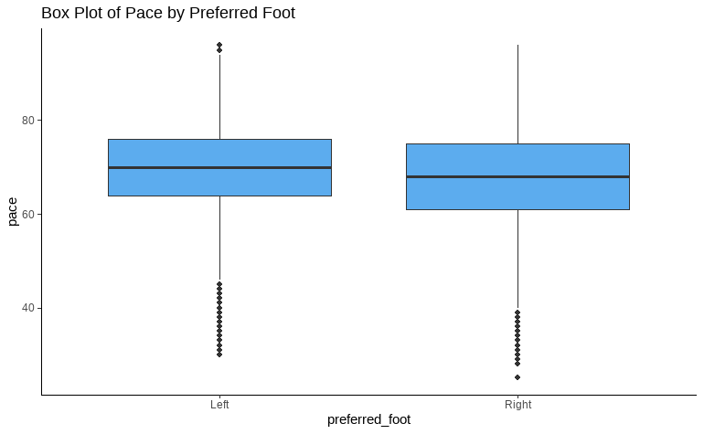

```r
ggplot(temp_df, aes(x=preferred_foot, y=pace)) +
  geom_boxplot(fill="steelblue2") +
  theme_classic() +
  labs(title="Box Plot of Pace by Preferred Foot")
```

From the above plot, the median of the pace of players who prefer to use their left foot is higher than that of players who prefer to use their right. This relationship could be explored further.

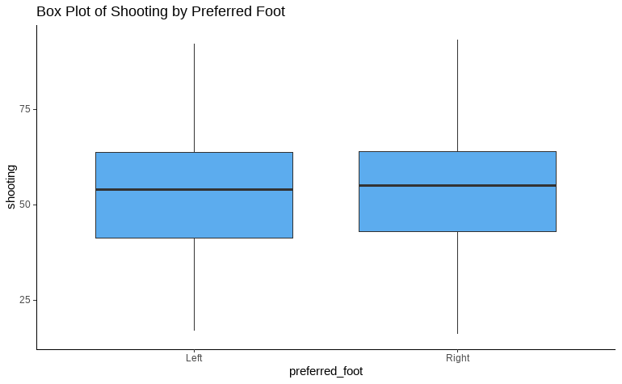

```r
ggplot(temp_df, aes(x=preferred_foot, y=shooting)) +
  geom_boxplot(fill="steelblue2") +
  theme_classic() +
  labs(title="Box Plot of Shooting by Preferred Foot")
```

Shooting ability does not seem to be determined by player preferred foot, from the above diagram, as the medians are not significantly apart.

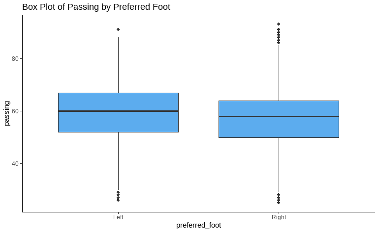

```r
ggplot(temp_df, aes(x=preferred_foot, y=passing)) +
  geom_boxplot(fill="steelblue2") +
  theme_classic() +
  labs(title="Box Plot of Passing by Preferred Foot")
```

Left footed players seem to have slightly better median passing ability than right footed players, although the difference is not so significant.

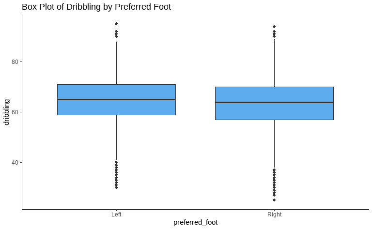

```r
ggplot(temp_df, aes(x=preferred_foot, y=dribbling)) +
  geom_boxplot(fill="steelblue2") +
  theme_classic() +
  labs(title="Box Plot of Dribbling by Preferred Foot")
```

The median dribbling ability of left footed players shows to be slightly higher than that of the right footed players, from the above plot.

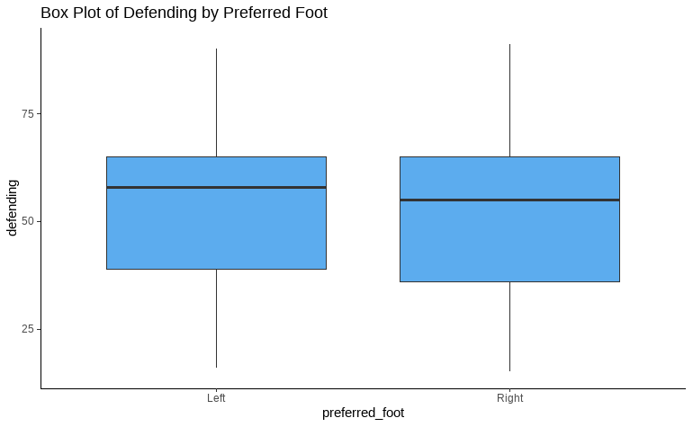

```r
ggplot(temp_df, aes(x=preferred_foot, y=defending)) +
  geom_boxplot(fill="steelblue2") +
  theme_classic() +
  labs(title="Box Plot of Defending by Preferred Foot")
```

The median defending ability for a player whose preferred foot is the left, is higher than that of a player whose preferred foot is the right.

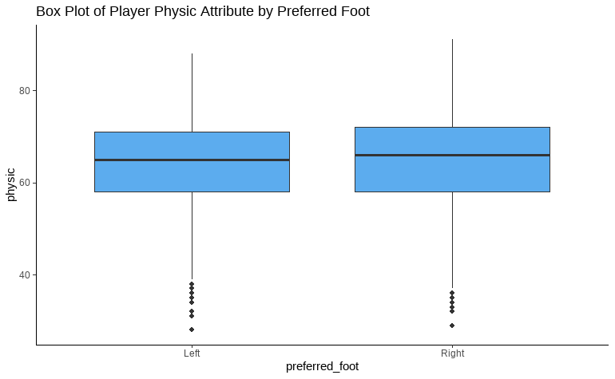

```r
ggplot(temp_df, aes(x=preferred_foot, y=physic)) +
  geom_boxplot(fill="steelblue2") +
  theme_classic() +
  labs(title="Box Plot of Player Physic Attribute by Preferred Foot")
```

There doesn’t seem to be a significant difference in median physical ability based on player preferred foot.

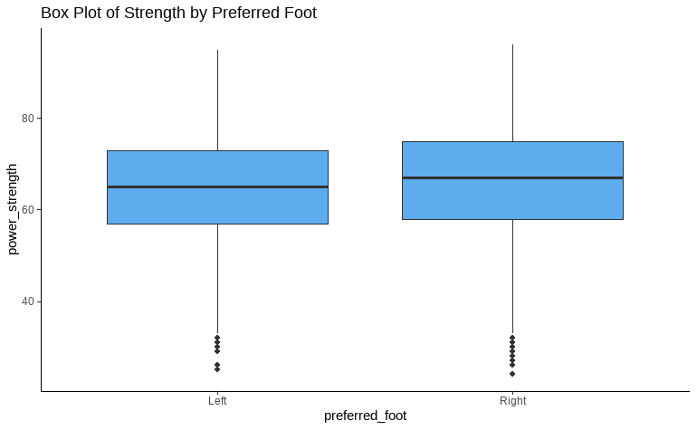

```r
ggplot(temp_df, aes(x=preferred_foot, y=power_strength)) +
  geom_boxplot(fill="steelblue2") +
  theme_classic() +
  labs(title="Box Plot of Strength by Preferred Foot")
```

There doesn’t seem to be a significant difference in the median strength of a player based on their preferred foot, though the it is slightly higher for right footed players.

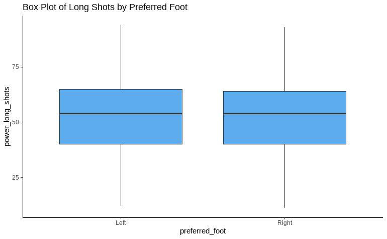

```r
ggplot(temp_df, aes(x=preferred_foot, y=power_long_shots)) +
  geom_boxplot(fill="steelblue2") +
  theme_classic() +
  labs(title="Box Plot of Long Shots by Preferred Foot")
```

The median long shot ability is similar for players regardless of their preferred foot. The difference is not significant.

# By High Wage Indicator

```r

ggplot(temp_df, aes(x=high.wage.ind, y=potential)) + geom_boxplot(fill=“steelblue2”) + theme_classic() + labs(title=“Box Plot of Potential by High Wage Indicator”)

```

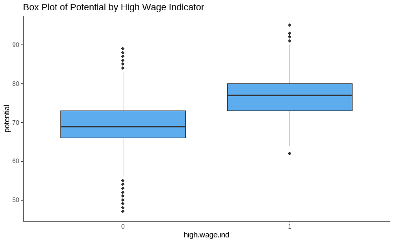

The median potential for players with higher wages is significantly higher than that for players with lower wages, hinting at a possible relationship between those two variables.

`r ggplot(temp_df, aes(x=high.wage.ind, y=wage_eur)) + geom_boxplot(fill="steelblue2") + theme_classic() + labs(title="Box Plot of Weekly Wage by High Wage Indicator")`

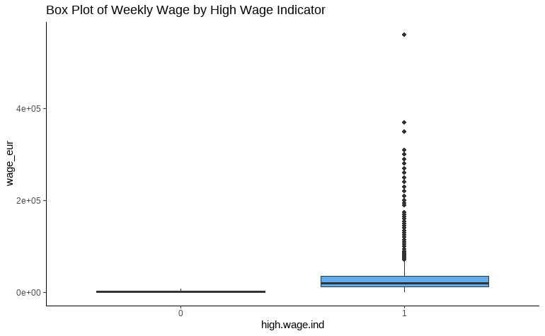

The median wage for high wage players is higher than the median wage for low wage players, as we would expect.

`r ggplot(temp_df, aes(x=high.wage.ind, y=age)) + geom_boxplot(fill="steelblue2") + theme_classic() + labs(title="Box Plot of Age by High Wage Indicator")`

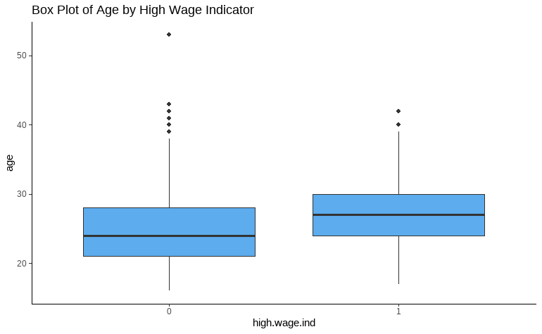

The median age of players with higher wages seems to be higher than the median age of players with lower wages. This could indicate that there may be a relationship between those two variables, and they may have to be looked at later. Younger (and most likely inexperienced) players are usually not paid as much as their senior and more experienced counterparts in most organisations

`r ggplot(temp_df, aes(x=high.wage.ind, y=height_cm)) + geom_boxplot(fill="steelblue2") + theme_classic() + labs(title="Box Plot of Height by High Wage Indicator")`

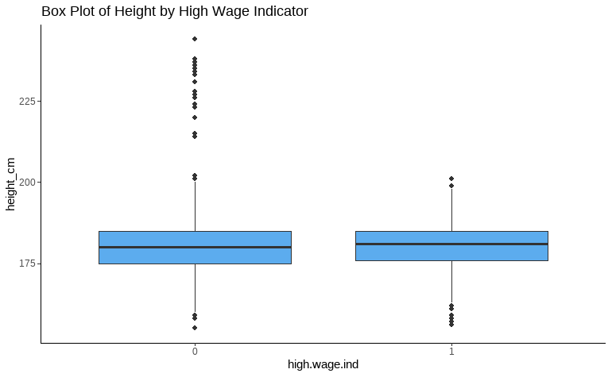

There doesn’t seem to be a significat difference in the median height of a player based on their high wage status.

`r ggplot(temp_df, aes(x=high.wage.ind, y=weight_kg)) + geom_boxplot(fill="steelblue2") + theme_classic() + labs(title="Box Plot of Weight by High Wage Indicator")`

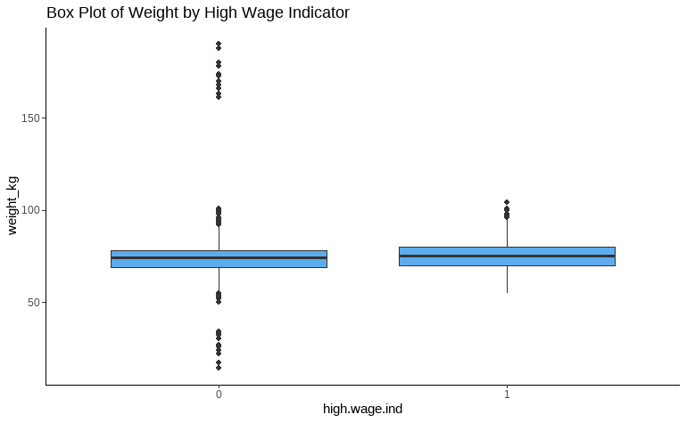

The difference in median weight of a player based on high wage status is not very significant, from the above diagram.

`r ggplot(temp_df, aes(x=high.wage.ind, y=pace)) + geom_boxplot(fill="steelblue2") + theme_classic() + labs(title="Box Plot of Pace by High Wage Indicator")`

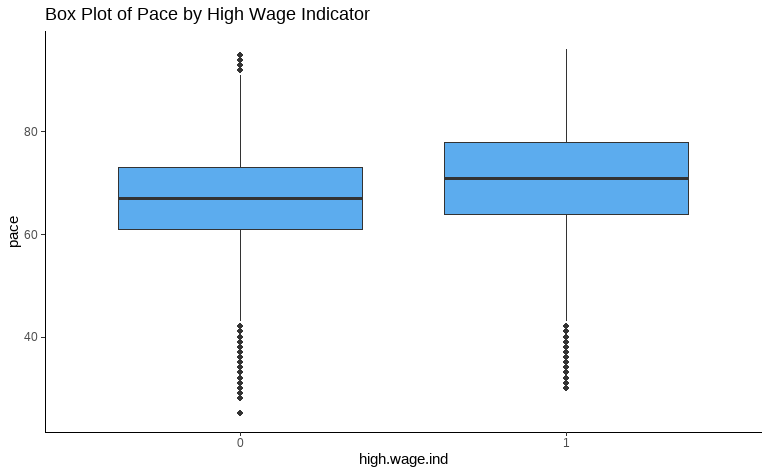

From the above plot, we can see that there is a significant difference in median pace of players with higher wage status and players with low wage status. This relationship can be probed further if required, at a later stage.

`r ggplot(temp_df, aes(x=high.wage.ind, y=shooting)) + geom_boxplot(fill="steelblue2") + theme_classic() + labs(title="Box Plot of Shooting by High Wage Indicator")`

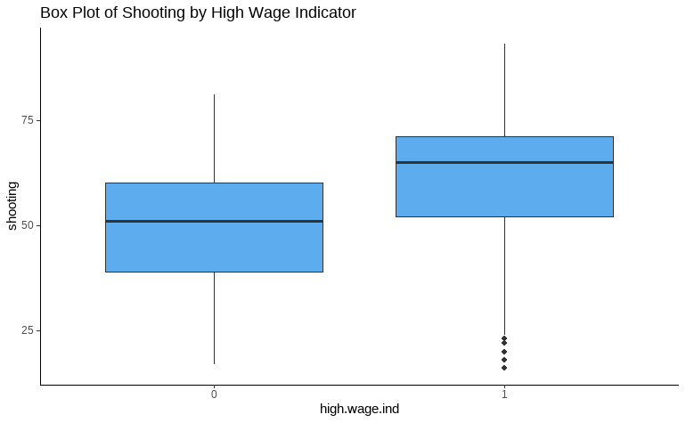

We clearly see that the median shooting ability for players with high wage status is significantly higher than the median shooting ability for players with low wage status. This points to a relationship between these two variables.

`r ggplot(temp_df, aes(x=high.wage.ind, y=passing)) + geom_boxplot(fill="steelblue2") + theme_classic() + labs(title="Box Plot of Passing by High Wage Indicator")`

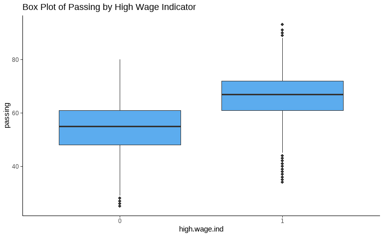

The median passing ability for players with high wage status is significantly higher than the median passing ability for players with low wage status. This is a relationship that can be explored later.

`r ggplot(temp_df, aes(x=high.wage.ind, y=dribbling)) + geom_boxplot(fill="steelblue2") + theme_classic() + labs(title="Box Plot of Dribbling by High Wage Indicator")`

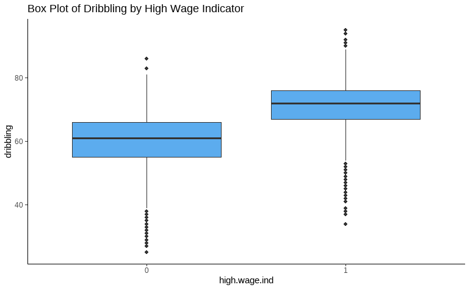

The median dribbling ability for players with high wage status is significantly higher than that for players with a low wage status, from the plot above. This points to a potential relationship between “dribbling” and “high.wage.ind”.

`r ggplot(temp_df, aes(x=high.wage.ind, y=defending)) + geom_boxplot(fill="steelblue2") + theme_classic() + labs(title="Box Plot of Defending by High Wage Indicator")`

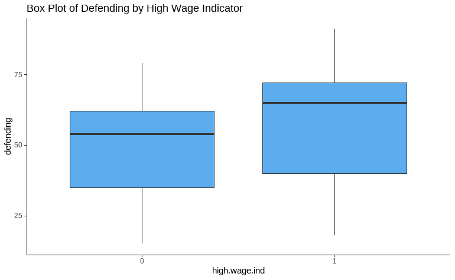

There is a significant difference in the median defending ability of players who are of a higher wage status, and players who are of a lower wage status.

`r ggplot(temp_df, aes(x=high.wage.ind, y=physic)) + geom_boxplot(fill="steelblue2") + theme_classic() + labs(title="Box Plot of Player Physic Attribute by High Wage Indicator")`

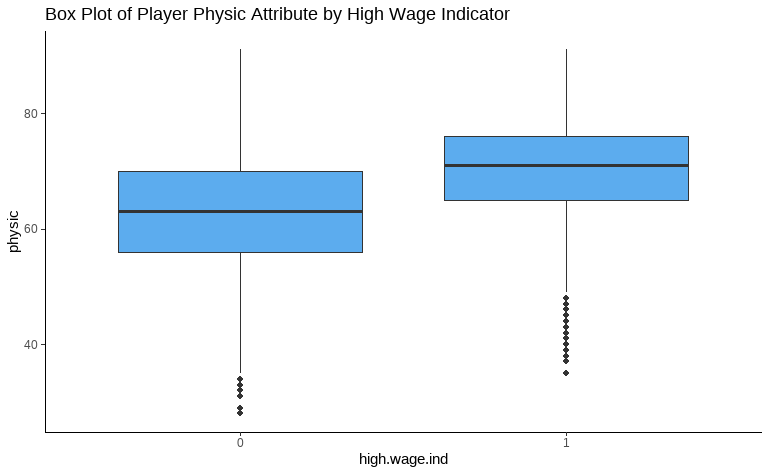

There is a significant difference in the median physical ability of players who are of a higher wage status, and players who are of a lower wage status.

`r ggplot(temp_df, aes(x=high.wage.ind, y=power_strength)) + geom_boxplot(fill="steelblue2") + theme_classic() + labs(title="Box Plot of Strength by High Wage Indicator")`

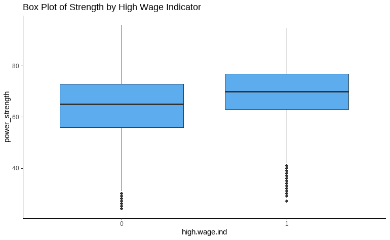

There is a significant difference in the median strength of players who are of a higher wage status, and players who are of a lower wage status.

`r ggplot(temp_df, aes(x=high.wage.ind, y=power_long_shots)) + geom_boxplot(fill="steelblue2") + theme_classic() + labs(title="Box Plot of Long Shots by High Wage Indicator")`

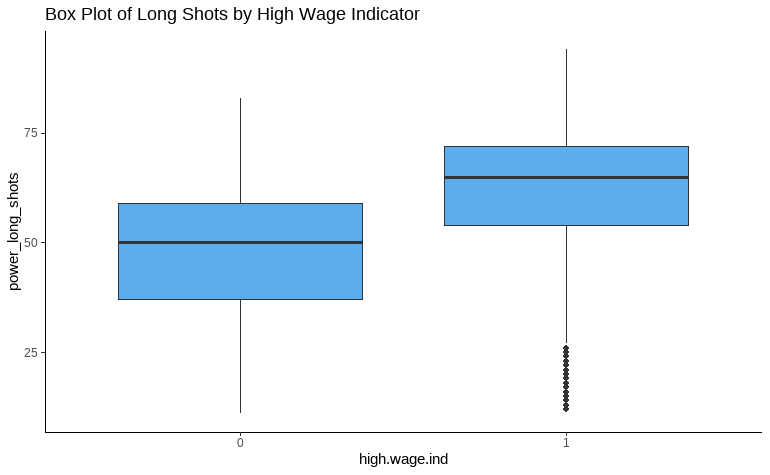

There is a significant difference in the median long shot ability of players who are of a higher wage status, and players who are of a lower wage status.

If anything can be taken from the previous section, it’s that better players are paid much better.

## Multivariate analyses

I create a subset of the data frame but with only the numerical variables. This will enable the plots of correlation matrices to be performed with ease.

```r
numeric_temp_df <- subset(temp_df, select = c(potential, wage_eur,age,height_cm,weight_kg,pace,shooting,passing,dribbling,defending,physic,power_strength,power_long_shots))
```

Now we check the structure of the new subset, to make sure that only numerical variables are present.

```r
str(numeric_temp_df)
```

```
'data.frame':   12744 obs. of  13 variables:
 $ potential       : int  93 92 91 91 91 91 90 90 95 89 ...
 $ wage_eur        : num  560000 220000 240000 270000 370000 210000 250000 250000 160000 300000 ...
 $ age             : int  33 35 31 28 29 28 28 28 21 32 ...
 $ height_cm       : int  170 187 184 175 181 193 175 175 178 173 ...
 $ weight_kg       : int  72 83 80 68 70 92 69 71 73 70 ...
 $ pace            : int  85 89 78 91 76 76 94 93 96 78 ...
 $ shooting        : int  92 93 91 85 86 60 85 86 86 90 ...
 $ passing         : int  91 81 78 86 93 71 80 81 78 77 ...
 $ dribbling       : int  95 89 85 94 88 71 90 90 91 88 ...
 $ defending       : int  38 35 43 36 64 91 44 45 39 33 ...
 $ physic          : int  65 77 82 59 78 86 76 75 76 73 ...
 $ power_strength  : int  69 78 86 50 74 92 70 75 76 74 ...
 $ power_long_shots: int  94 93 85 84 91 64 78 84 79 84 ...
```

We can see that only numerical variables are present, so we can perform the tests for correlation between the numerical variables.

From the “dlookr” package we can use the correlate function and it is worth noting that it computes the Pearson correlation by default (Zablotski, 2021). Pearson measures the degree of the relationship between linearly related variables (Sarmento, n.d.).

```r
correlate(temp_df,potential)
```

| var1 | var2 | coef_corr |
| --- | --- | --- |
| potential | wage_eur | 0.507763346 |
| potential | age | -0.255671405 |
| potential | height_cm | 0.028205664 |
| potential | weight_kg | 0.001060633 |
| potential | pace | 0.293819570 |
| potential | shooting | 0.326956802 |
| potential | passing | 0.472239302 |
| potential | dribbling | 0.513608607 |
| potential | defending | 0.184400995 |
| potential | physic | 0.203992953 |

[output cut: 2 more lines]

To plot the correlation matrix, I would use the Kendall correlation to do so. This is because the Kendall is more suited to measuring the strength of the dependence between two variables, without the assumption of them being normally distributed like Pearson assumes (Correlation (Pearson, Kendall, Spearman) - Statistics Solutions, n.d.).

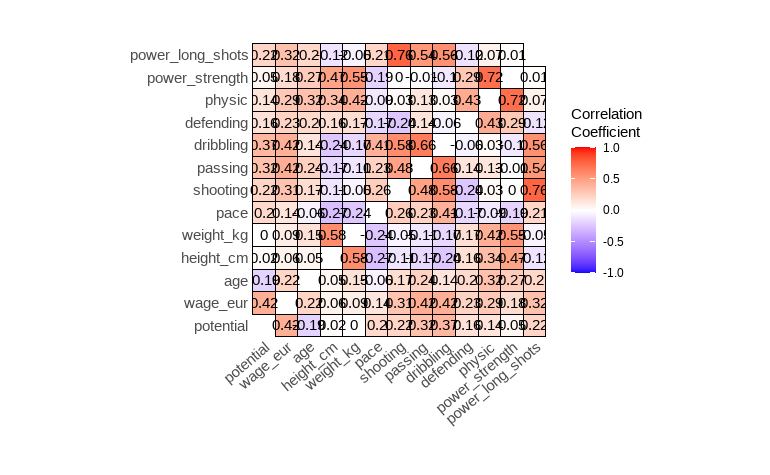

```r
plot_correlate(temp_df, method = "kendall")
```

From the matrix above, we can see that the variables that show the highest levels of correlative dependence with potential are “wage_eur”, “age”(albeit in a negative direction), “passing”, “shooting”, “dribbling” and “power_long_shots”.

Now I check for multi-colinearity.

```r
cor(numeric_temp_df)
```

```
                    potential   wage_eur        age   height_cm    weight_kg       pace    shooting     passing   dribbling  defending      physic
potential         1.000000000 0.50776335 -0.2556714  0.02820566  0.001060633  0.2938196  0.32695680  0.47223930  0.51360861  0.1844010  0.20399295
wage_eur          0.507763346 1.00000000  0.1659937  0.04228634  0.076685564  0.1532870  0.33038331  0.45356040  0.42134569  0.1914478  0.26170864
age              -0.255671405 0.16599368  1.0000000  0.05510090  0.198315825 -0.1713278  0.23036121  0.32952768  0.17473080  0.2573333  0.43097532
height_cm         0.028205664 0.04228634  0.0551009  1.00000000  0.640607734 -0.3799802 -0.17322285 -0.24178099 -0.34191727  0.2034197  0.46016520
weight_kg         0.001060633 0.07668556  0.1983158  0.64060773  1.000000000 -0.3240972 -0.07250744 -0.14268589 -0.23500817  0.1904006  0.52237143
pace              0.293819570 0.15328698 -0.1713278 -0.37998018 -0.324097170  1.0000000  0.36184931  0.31795484  0.55052537 -0.2640195 -0.15710275
shooting          0.326956802 0.33038331  0.2303612 -0.17322285 -0.072507437  0.3618493  1.00000000  0.66526299  0.77654944 -0.3859524  0.03761453
passing           0.472239302 0.45356040  0.3295277 -0.24178099 -0.142685886  0.3179548  0.66526299  1.00000000  0.83859170  0.1777460  0.19064976
dribbling         0.513608607 0.42134569  0.1747308 -0.34191727 -0.235008169  0.5505254  0.77654944  0.83859170  1.00000000 -0.1280711  0.02266447
defending         0.184400995 0.19144778  0.2573333  0.20341972  0.190400580 -0.2640195 -0.38595238  0.17774599 -0.12807108  1.0000000  0.56008416
physic            0.203992953 0.26170864  0.4309753  0.46016520  0.522371433 -0.1571028  0.03761453  0.19064976  0.02266447  0.5600842  1.00000000
power_strength    0.075838983 0.15668404  0.3699414  0.60639289  0.655531939 -0.3017180 -0.01890254 -0.01743833 -0.15511423  0.3680452  0.89073598
power_long_shots  0.313801257 0.32268147  0.2640681 -0.18866784 -0.081093462  0.3088938  0.92462195  0.71668743  0.75498493 -0.2281414  0.08628199
                 power_strength power_long_shots
potential           0.075838983      0.313801257
wage_eur            0.156684044      0.322681467
age                 0.369941411      0.264068080
height_cm           0.606392889     -0.188667842
weight_kg           0.655531939     -0.081093462
pace               -0.301717987      0.308893784
shooting           -0.018902539      0.924621951
passing            -0.017438330      0.716687429
dribbling          -0.155114233      0.754984934
defending           0.368045229     -0.228141437
physic              0.890735977      0.086281991
power_strength      1.000000000     -0.008678709
power_long_shots   -0.008678709      1.000000000
```

The next plot shows the variables which are not significant with regard to how much they correlate with “potential.”

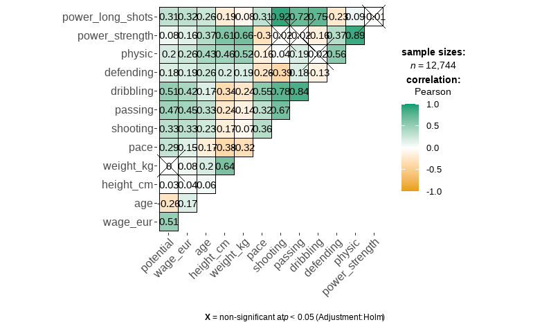

```r
ggcorrmat(data = numeric_temp_df,)
```

## 2.3 Additional insights and issues

- A potential issue that may come up could do with the variables that are not normally distributed. For such variables, how they will affect the model cannot be predicted at this stage, but some of these variables may require transformation. It is necessary to keep that in mind going forward.
- The outlier values in “temp_df”, as compared to “temp2_df” will have to be noted when the models are built, in order to observe the effects of such an outlier on a model.

# 3. Modelling

## 3.1 Build a model for player potential

**Analysis Plan**

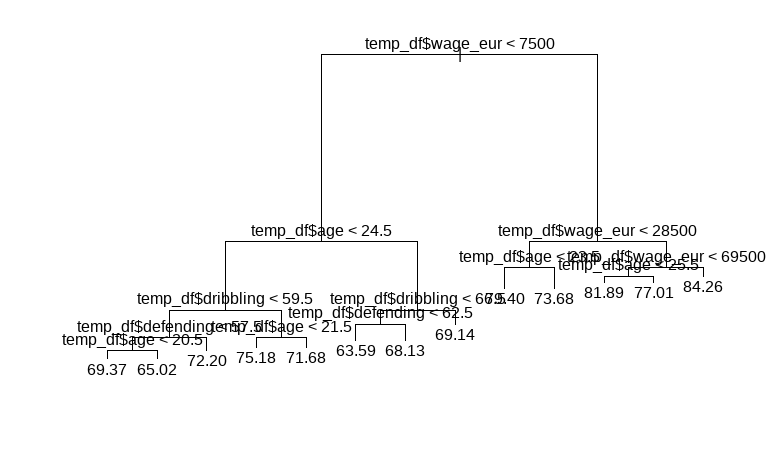

```r
model.tree<-tree(temp_df$potential~temp_df$wage_eur+temp_df$age+temp_df$height_cm+temp_df$weight_kg+temp_df$preferred_foot+temp_df$pace+temp_df$shooting+temp_df$passing+temp_df$dribbling+temp_df$defending+temp_df$physic+temp_df$power_strength+temp_df$power_long_shots+temp_df$high.wage.ind)
plot(model.tree)

text(model.tree)
```

The above plot shows that “wage_eur” is the most important factor affecting “potential.” “age” is important at both high and low “wage_eur”. We also see that there are a good number of interactions going on in the data set, with some being two-way or three-way interactions. Due to this, I will not use any interactions for this model as, with the kind of model I will build will have many explanatory variables and so adding too many interactions will generate an overly complex model that will require a larger sample of data to be able to model it.

- I would find out if the relationship between my response variable and explanatory variables is linear. In (2.2), I concluded that the data points to having a linear relationship between response and explanatory variables.
- I would check to see if I have a big enough sample. With over 500 rows of data in the data frames, I can conclude that this is so.
- Then finally, I would build a maximal model first, and then attempt to simplify it to its most useful elements.

**Model Building**

Now, I will build the model. I would start by building a maximal model for potential, using all variables (continuous or otherwise).

```r
potential_maximal_model.lm <- lm(temp_df$potential~temp_df$wage_eur+temp_df$age+temp_df$height_cm+temp_df$weight_kg+temp_df$preferred_foot+temp_df$pace+temp_df$shooting+temp_df$passing+temp_df$dribbling+temp_df$defending+temp_df$physic+temp_df$power_strength+temp_df$power_long_shots+temp_df$high.wage.ind)

summary.lm(potential_maximal_model.lm)
```

```
Call:
lm(formula = temp_df$potential ~ temp_df$wage_eur + temp_df$age +
    temp_df$height_cm + temp_df$weight_kg + temp_df$preferred_foot +
    temp_df$pace + temp_df$shooting + temp_df$passing + temp_df$dribbling +
    temp_df$defending + temp_df$physic + temp_df$power_strength +
    temp_df$power_long_shots + temp_df$high.wage.ind)

Residuals:
     Min       1Q   Median       3Q      Max
-15.4523  -2.3299  -0.1098   2.3184  15.0834

Coefficients:
                              Estimate Std. Error t value Pr(>|t|)
(Intercept)                  4.954e+01  1.243e+00  39.860  < 2e-16 ***
temp_df$wage_eur             4.903e-05  1.789e-06  27.403  < 2e-16 ***
temp_df$age                 -7.749e-01  8.541e-03 -90.732  < 2e-16 ***
temp_df$height_cm            5.663e-02  6.908e-03   8.198 2.68e-16 ***
temp_df$weight_kg            3.061e-03  6.197e-03   0.494 0.621391
temp_df$preferred_footRight -1.676e-02  7.494e-02  -0.224 0.823051
temp_df$pace                -5.145e-03  4.039e-03  -1.274 0.202770
temp_df$shooting             1.071e-01  8.045e-03  13.310  < 2e-16 ***
temp_df$passing              2.819e-02  7.540e-03   3.738 0.000186 ***
temp_df$dribbling            2.520e-01  8.370e-03  30.110  < 2e-16 ***
temp_df$defending            9.825e-02  3.925e-03  25.034  < 2e-16 ***
temp_df$physic               4.072e-02  1.039e-02   3.919 8.93e-05 ***
temp_df$power_strength       4.207e-02  7.807e-03   5.389 7.21e-08 ***
temp_df$power_long_shots    -6.937e-02  5.921e-03 -11.716  < 2e-16 ***
temp_df$high.wage.ind1       3.159e+00  9.618e-02  32.839  < 2e-16 ***
---
Signif. codes:  0 ‘***’ 0.001 ‘**’ 0.01 ‘*’ 0.05 ‘.’ 0.1 ‘ ’ 1

Residual standard error: 3.624 on 12729 degrees of freedom
Multiple R-squared:  0.676, Adjusted R-squared:  0.6757
F-statistic:  1897 on 14 and 12729 DF,  p-value: < 2.2e-16
```

From the maximal model, it can be seen that the prediction of “potential” is most dependent on the variables “wage_eur”, “age”, “dribbling”, “shooting”, “passing”, “power_strength”, “high.wage.ind1”, “defending”, “height_cm”, “physic”, and,“power_long_shots”. In all these cases, except for that of “age” and “power_long_shots”, an increase in their values accounts for an increase in the estimate for “potential”.

I will build the minimal adequate model in the chunk below, to see how the step function would simplify the model.

```r
potential_minimal_model.lm <- step(potential_maximal_model.lm)
```

```
Start:  AIC=32830.05
temp_df$potential ~ temp_df$wage_eur + temp_df$age + temp_df$height_cm +
    temp_df$weight_kg + temp_df$preferred_foot + temp_df$pace +
    temp_df$shooting + temp_df$passing + temp_df$dribbling +
    temp_df$defending + temp_df$physic + temp_df$power_strength +
    temp_df$power_long_shots + temp_df$high.wage.ind

                           Df Sum of Sq    RSS   AIC
- temp_df$preferred_foot    1         1 167139 32828
- temp_df$weight_kg         1         3 167142 32828
- temp_df$pace              1        21 167160 32830
<none>                                  167139 32830
- temp_df$passing           1       184 167322 32842
- temp_df$physic            1       202 167340 32843
- temp_df$power_strength    1       381 167520 32857
- temp_df$height_cm         1       882 168021 32895
- temp_df$power_long_shots  1      1802 168941 32965
- temp_df$shooting          1      2326 169465 33004
- temp_df$defending         1      8229 175367 33441
- temp_df$wage_eur          1      9860 176999 33559
- temp_df$dribbling         1     11904 179043 33705
- temp_df$high.wage.ind     1     14160 181299 33864
- temp_df$age               1    108095 275234 39185

Step:  AIC=32828.1
temp_df$potential ~ temp_df$wage_eur + temp_df$age + temp_df$height_cm +
    temp_df$weight_kg + temp_df$pace + temp_df$shooting + temp_df$passing +
    temp_df$dribbling + temp_df$defending + temp_df$physic +
    temp_df$power_strength + temp_df$power_long_shots + temp_df$high.wage.ind

                           Df Sum of Sq    RSS   AIC
- temp_df$weight_kg         1         3 167143 32826
- temp_df$pace              1        21 167160 32828
<none>                                  167139 32828
- temp_df$passing           1       185 167325 32840
- temp_df$physic            1       201 167341 32841
- temp_df$power_strength    1       384 167523 32855
- temp_df$height_cm         1       884 168023 32893
- temp_df$power_long_shots  1      1802 168942 32963
- temp_df$shooting          1      2332 169471 33003
```

[output cut: 31 more lines]

```
    temp_df$power_long_shots + temp_df$high.wage.ind

                           Df Sum of Sq    RSS   AIC
<none>                                  167164 32826
- temp_df$physic            1       178 167343 32838
- temp_df$passing           1       202 167367 32839
- temp_df$power_strength    1       492 167656 32861
- temp_df$height_cm         1      1111 168276 32908
- temp_df$power_long_shots  1      1785 168950 32959
- temp_df$shooting          1      2355 169520 33002
- temp_df$defending         1      8719 175884 33472
- temp_df$wage_eur          1      9863 177027 33555
- temp_df$dribbling         1     13590 180755 33820
- temp_df$high.wage.ind     1     14196 181360 33863
- temp_df$age               1    112598 279762 39387
```

```r
 final_potential_minimal_model.lm <- lm(temp_df$potential ~ temp_df$wage_eur + temp_df$age + temp_df$height_cm + temp_df$shooting + temp_df$dribbling + temp_df$defending + temp_df$physic + temp_df$power_long_shots + temp_df$high.wage.ind)

summary.lm(final_potential_minimal_model.lm)
```

```
Call:
lm(formula = temp_df$potential ~ temp_df$wage_eur + temp_df$age +
    temp_df$height_cm + temp_df$shooting + temp_df$dribbling +
    temp_df$defending + temp_df$physic + temp_df$power_long_shots +
    temp_df$high.wage.ind)

Residuals:
     Min       1Q   Median       3Q      Max
-15.3111  -2.3394  -0.1184   2.3108  15.2681

Coefficients:
                           Estimate Std. Error t value Pr(>|t|)
(Intercept)               4.681e+01  1.136e+00   41.22   <2e-16 ***
temp_df$wage_eur          4.949e-05  1.790e-06   27.65   <2e-16 ***
temp_df$age              -7.612e-01  8.189e-03  -92.95   <2e-16 ***
temp_df$height_cm         7.273e-02  5.972e-03   12.18   <2e-16 ***
temp_df$shooting          1.112e-01  8.006e-03   13.89   <2e-16 ***
temp_df$dribbling         2.568e-01  6.026e-03   42.61   <2e-16 ***
temp_df$defending         9.918e-02  3.243e-03   30.59   <2e-16 ***
temp_df$physic            8.644e-02  5.061e-03   17.08   <2e-16 ***
temp_df$power_long_shots -6.568e-02  5.825e-03  -11.28   <2e-16 ***
temp_df$high.wage.ind1    3.178e+00  9.627e-02   33.02   <2e-16 ***
---
Signif. codes:  0 ‘***’ 0.001 ‘**’ 0.01 ‘*’ 0.05 ‘.’ 0.1 ‘ ’ 1

Residual standard error: 3.631 on 12734 degrees of freedom
Multiple R-squared:  0.6746,    Adjusted R-squared:  0.6744
F-statistic:  2934 on 9 and 12734 DF,  p-value: < 2.2e-16
```

The minimal model equation now looks like:

$$potential= 46.81 + 0.00004949\times wage\_eur - 0.7612 \times age + 0.07273\times height\_cm + 0.1112 \times shooting+ 0.2568\times dribbling + 0.09918 \times defending + 0.08644\times physic - 0.06568\times power\_long\_shots + 3.178\times high.wage.ind1$$

## 3.2 Critique model using relevant diagnostics

- We can see that for each variable in the model, “potential” is inversely related to “age” and “power_long_shots”, but for the other constituent variables of the model, any increase in their values results in an increase in the predicted value of “potential”.
- From 3.1, we can see that the model has a more than 60% goodness of fit with a significant F-statistic. All the coefficients of the model are significant, hence there is no need to simplify further.

Next, I take a look at the diagnostic plots.

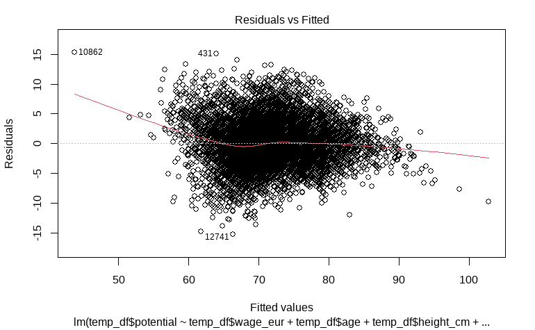

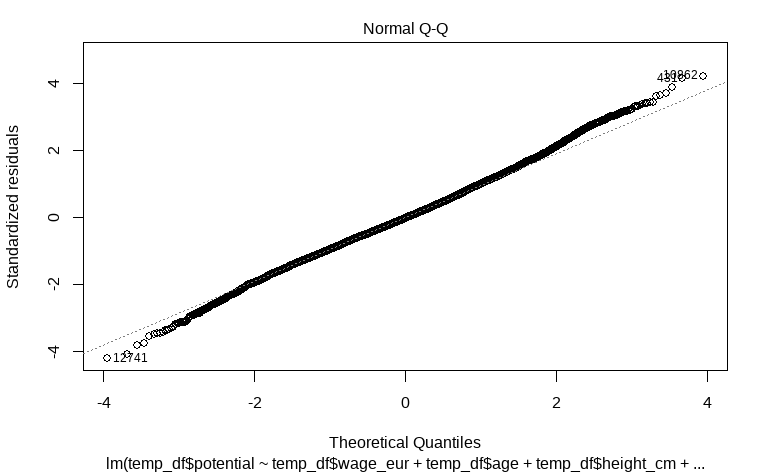

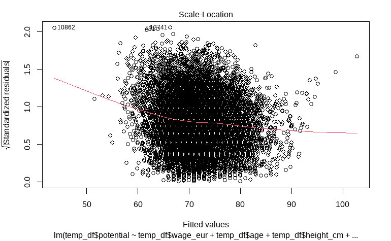

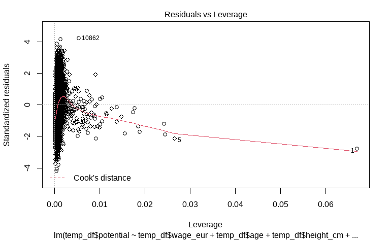

```r
plot(final_potential_minimal_model.lm)
```

The Q-Q plot also looks to be aligned, save a few outliers which can be looked at, if there is a need to.

**Potential weaknesses:**

- The model can easily be affected by outliers. We seem to have a considerable number of outliers showing in the plots and too many of them could have unforeseen effects on the model.
- There is also a tendency for the model to miss any non-linear relationships between variables.

# 4. Extension

## 4.1 Model the likelihood of a player having a weekly wage above 8000 Euro (using the high.wage.ind variable provided).

*Given this second research question (i.e., involving the binary target attribute) provide a plan of analysis based on relevant EDA for this attribute. The model is described, explained and critiqued.*

**Analysis Plan**

- I would check for outliers in the data set. The “wage_eur” outliers were checked in (1.3) and it was concluded that they did not violate any rules of data integrity, hence they were left in the data set.
- Check how “high.wage.ind” interacts with the other variables of the data set. I did this in (2.2) with the boxplots. Those plots only showed the quartiles and so, may not clearly depict the relationships among the variables. I would use all variables to build the model, so it shows which variables are actually significant in predicting “high.wage.ind”.

To find out what the interaction is between the only two binary variables in the data set (“high.wage.ind” and “preferred_foot”), we run the next chunk.

```r
table(temp_df$high.wage.ind, temp_df$preferred_foot)
```

```
    Left Right
  0 2197  6784
  1 1021  2742
```

```r
chisq.test(table(temp_df$high.wage.ind, temp_df$preferred_foot))
```

```
    Pearson's Chi-squared test with Yates' continuity correction

data:  table(temp_df$high.wage.ind, temp_df$preferred_foot)
X-squared = 9.8739, df = 1, p-value = 0.001676
```

- After all that is done, I will build the model.

## 4.2 Model Building, Description and Explanation

I will now build the logistic regression model for high wage indicator below. I would start off with a maximal model and then use stepwise selection to find out the minimal adequate model.

```r
wage_model.glm<-glm(temp_df$high.wage.ind~temp_df$potential+temp_df$wage_eur+temp_df$age+temp_df$height_cm+temp_df$weight_kg+temp_df$preferred_foot+temp_df$pace+temp_df$shooting+temp_df$passing+temp_df$dribbling+temp_df$defending+temp_df$physic+temp_df$power_strength+temp_df$power_long_shots, family = "binomial")
```

```
Warning: glm.fit: fitted probabilities numerically 0 or 1 occurred
```

```r
summary(wage_model.glm)
```

```
Call:
glm(formula = temp_df$high.wage.ind ~ temp_df$potential + temp_df$wage_eur +
    temp_df$age + temp_df$height_cm + temp_df$weight_kg + temp_df$preferred_foot +
    temp_df$pace + temp_df$shooting + temp_df$passing + temp_df$dribbling +
    temp_df$defending + temp_df$physic + temp_df$power_strength +
    temp_df$power_long_shots, family = "binomial")

Deviance Residuals:
   Min      1Q  Median      3Q     Max
-0.704   0.000   0.000   0.000   8.490

Coefficients:
                              Estimate Std. Error z value Pr(>|z|)
(Intercept)                 -3.117e+01  6.535e+00  -4.769 1.85e-06 ***
temp_df$potential           -1.047e-04  3.773e-02  -0.003    0.998
temp_df$wage_eur             3.708e-03  2.141e-04  17.322  < 2e-16 ***
temp_df$age                 -1.135e-02  4.144e-02  -0.274    0.784
temp_df$height_cm           -1.048e-02  3.217e-02  -0.326    0.745
temp_df$weight_kg            1.392e-02  3.183e-02   0.437    0.662
temp_df$preferred_footRight  1.600e-01  2.860e-01   0.559    0.576
temp_df$pace                -1.231e-02  1.433e-02  -0.859    0.390
temp_df$shooting             8.946e-03  3.119e-02   0.287    0.774
temp_df$passing             -1.062e-02  2.809e-02  -0.378    0.705
temp_df$dribbling            3.207e-02  3.584e-02   0.895    0.371
temp_df$defending            3.187e-03  1.633e-02   0.195    0.845
temp_df$physic               2.064e-03  3.994e-02   0.052    0.959
temp_df$power_strength      -5.130e-03  3.289e-02  -0.156    0.876
temp_df$power_long_shots    -6.075e-03  2.116e-02  -0.287    0.774
---
Signif. codes:  0 ‘***’ 0.001 ‘**’ 0.01 ‘*’ 0.05 ‘.’ 0.1 ‘ ’ 1

(Dispersion parameter for binomial family taken to be 1)

    Null deviance: 15466.3  on 12743  degrees of freedom
Residual deviance:   533.3  on 12729  degrees of freedom
AIC: 563.3

Number of Fisher Scoring iterations: 14
```

It is worth noting though that these warning messages aren’t error messages, and so, will allow the model to be fit.

Using stepwise selection now.

```r
step(wage_model.glm)
```

```
Start:  AIC=563.3
temp_df$high.wage.ind ~ temp_df$potential + temp_df$wage_eur +
    temp_df$age + temp_df$height_cm + temp_df$weight_kg + temp_df$preferred_foot +
    temp_df$pace + temp_df$shooting + temp_df$passing + temp_df$dribbling +
    temp_df$defending + temp_df$physic + temp_df$power_strength +
    temp_df$power_long_shots
```

```
                           Df Deviance    AIC
- temp_df$weight_kg         1    533.2  561.2
- temp_df$potential         1    533.3  561.3
- temp_df$physic            1    533.3  561.3
- temp_df$power_strength    1    533.3  561.3
- temp_df$defending         1    533.3  561.3
- temp_df$preferred_foot    1    533.3  561.3
- temp_df$height_cm         1    533.3  561.3
- temp_df$shooting          1    533.3  561.3
- temp_df$age               1    533.3  561.3
- temp_df$power_long_shots  1    533.3  561.3
- temp_df$dribbling         1    533.3  561.3
- temp_df$passing           1    533.4  561.4
- temp_df$pace              1    533.4  561.4
<none>                           533.3  563.3
- temp_df$wage_eur          1   7357.6 7385.6
```

```
Step:  AIC=561.24
temp_df$high.wage.ind ~ temp_df$potential + temp_df$wage_eur +
    temp_df$age + temp_df$height_cm + temp_df$preferred_foot +
    temp_df$pace + temp_df$shooting + temp_df$passing + temp_df$dribbling +
    temp_df$defending + temp_df$physic + temp_df$power_strength +
    temp_df$power_long_shots
```

```
                           Df Deviance    AIC
- temp_df$potential         1    533.2  559.2
- temp_df$physic            1    533.2  559.2
- temp_df$power_strength    1    533.2  559.2
- temp_df$preferred_foot    1    533.3  559.3
- temp_df$defending         1    533.3  559.3
- temp_df$height_cm         1    533.3  559.3
- temp_df$shooting          1    533.3  559.3
- temp_df$age               1    533.3  559.3
- temp_df$power_long_shots  1    533.3  559.3
- temp_df$dribbling         1    533.3  559.3
- temp_df$passing           1    533.3  559.3
- temp_df$pace              1    533.3  559.3
<none>                           533.2  561.2
- temp_df$wage_eur          1   7369.1 7395.1
```

```
Step:  AIC=559.24
temp_df$high.wage.ind ~ temp_df$wage_eur + temp_df$age + temp_df$height_cm +
    temp_df$preferred_foot + temp_df$pace + temp_df$shooting +
    temp_df$passing + temp_df$dribbling + temp_df$defending +
    temp_df$physic + temp_df$power_strength + temp_df$power_long_shots
```

```
                           Df Deviance    AIC
- temp_df$physic            1    533.2  557.2
- temp_df$power_strength    1    533.2  557.2
- temp_df$preferred_foot    1    533.2  557.2
- temp_df$defending         1    533.3  557.3
- temp_df$age               1    533.3  557.3
- temp_df$height_cm         1    533.3  557.3
- temp_df$dribbling         1    533.3  557.3
- temp_df$shooting          1    533.3  557.3
- temp_df$power_long_shots  1    533.3  557.3
- temp_df$passing           1    533.3  557.3
- temp_df$pace              1    533.3  557.3
<none>                           533.2  559.2
- temp_df$wage_eur          1   9119.9 9143.9
```

```
Step:  AIC=557.24
temp_df$high.wage.ind ~ temp_df$wage_eur + temp_df$age + temp_df$height_cm +
    temp_df$preferred_foot + temp_df$pace + temp_df$shooting +
    temp_df$passing + temp_df$dribbling + temp_df$defending +
    temp_df$power_strength + temp_df$power_long_shots
```

```
                           Df Deviance    AIC
- temp_df$power_strength    1    533.2  555.2
- temp_df$preferred_foot    1    533.3  555.3
- temp_df$age               1    533.3  555.3
- temp_df$height_cm         1    533.3  555.3
- temp_df$defending         1    533.3  555.3
- temp_df$dribbling         1    533.3  555.3
- temp_df$shooting          1    533.3  555.3
- temp_df$power_long_shots  1    533.3  555.3
- temp_df$passing           1    533.3  555.3
- temp_df$pace              1    533.3  555.3
<none>                           533.2  557.2
- temp_df$wage_eur          1   9128.0 9150.0
```

```
Step:  AIC=555.25
temp_df$high.wage.ind ~ temp_df$wage_eur + temp_df$age + temp_df$height_cm +
    temp_df$preferred_foot + temp_df$pace + temp_df$shooting +
    temp_df$passing + temp_df$dribbling + temp_df$defending +
    temp_df$power_long_shots
```

```
                           Df Deviance    AIC
- temp_df$preferred_foot    1    533.3  553.3
- temp_df$defending         1    533.3  553.3
- temp_df$age               1    533.3  553.3
- temp_df$shooting          1    533.3  553.3
- temp_df$dribbling         1    533.3  553.3
- temp_df$power_long_shots  1    533.3  553.3
- temp_df$height_cm         1    533.3  553.3
- temp_df$passing           1    533.3  553.3
- temp_df$pace              1    533.3  553.3
<none>                           533.2  555.2
- temp_df$wage_eur          1   9354.4 9374.4
```

```
Step:  AIC=553.25
temp_df$high.wage.ind ~ temp_df$wage_eur + temp_df$age + temp_df$height_cm +
    temp_df$pace + temp_df$shooting + temp_df$passing + temp_df$dribbling +
    temp_df$defending + temp_df$power_long_shots
```

```
                           Df Deviance    AIC
- temp_df$defending         1    533.3  551.3
- temp_df$dribbling         1    533.3  551.3
- temp_df$age               1    533.3  551.3
- temp_df$shooting          1    533.3  551.3
- temp_df$power_long_shots  1    533.3  551.3
- temp_df$height_cm         1    533.3  551.3
- temp_df$passing           1    533.3  551.3
- temp_df$pace              1    533.4  551.4
<none>                           533.3  553.3
- temp_df$wage_eur          1   9355.0 9373.0
```

```
Step:  AIC=551.27
temp_df$high.wage.ind ~ temp_df$wage_eur + temp_df$age + temp_df$height_cm +
    temp_df$pace + temp_df$shooting + temp_df$passing + temp_df$dribbling +
    temp_df$power_long_shots
```

```
                           Df Deviance     AIC
- temp_df$shooting          1    533.3   549.3
- temp_df$age               1    533.3   549.3
- temp_df$dribbling         1    533.3   549.3
- temp_df$power_long_shots  1    533.3   549.3
- temp_df$height_cm         1    533.3   549.3
- temp_df$passing           1    533.3   549.3
- temp_df$pace              1    533.4   549.4
<none>                           533.3   551.3
- temp_df$wage_eur          1  10070.7 10086.7
```

```
Step:  AIC=549.29
temp_df$high.wage.ind ~ temp_df$wage_eur + temp_df$age + temp_df$height_cm +
    temp_df$pace + temp_df$passing + temp_df$dribbling + temp_df$power_long_shots
```

```
                           Df Deviance     AIC
- temp_df$power_long_shots  1    533.3   547.3
- temp_df$age               1    533.3   547.3
- temp_df$height_cm         1    533.3   547.3
- temp_df$dribbling         1    533.4   547.4
- temp_df$passing           1    533.4   547.4
- temp_df$pace              1    533.4   547.4
<none>                           533.3   549.3
- temp_df$wage_eur          1  10074.0 10088.0
```

```
Step:  AIC=547.29
temp_df$high.wage.ind ~ temp_df$wage_eur + temp_df$age + temp_df$height_cm +
    temp_df$pace + temp_df$passing + temp_df$dribbling
```

```
                    Df Deviance     AIC
- temp_df$height_cm  1    533.3   545.3
- temp_df$age        1    533.3   545.3
- temp_df$dribbling  1    533.3   545.3
- temp_df$pace       1    533.4   545.4
- temp_df$passing    1    533.4   545.4
<none>                    533.3   547.3
- temp_df$wage_eur   1  10174.1 10186.1
```

```
Step:  AIC=545.31
temp_df$high.wage.ind ~ temp_df$wage_eur + temp_df$age + temp_df$pace +
    temp_df$passing + temp_df$dribbling
```

```
                    Df Deviance     AIC
- temp_df$age        1    533.3   543.3
- temp_df$pace       1    533.4   543.4
- temp_df$passing    1    533.4   543.4
- temp_df$dribbling  1    533.4   543.4
<none>                    533.3   545.3
- temp_df$wage_eur   1  10915.9 10925.9
```

```
Step:  AIC=543.33
temp_df$high.wage.ind ~ temp_df$wage_eur + temp_df$pace + temp_df$passing +
    temp_df$dribbling
```

```
                    Df Deviance     AIC
- temp_df$pace       1    533.4   541.4
- temp_df$dribbling  1    533.4   541.4
- temp_df$passing    1    533.5   541.5
<none>                    533.3   543.3
- temp_df$wage_eur   1  10978.3 10986.3
```

```
Step:  AIC=541.37
temp_df$high.wage.ind ~ temp_df$wage_eur + temp_df$passing +
    temp_df$dribbling
```

```
                    Df Deviance     AIC
- temp_df$passing    1    533.4   539.4
- temp_df$dribbling  1    533.4   539.4
<none>                    533.4   541.4
- temp_df$wage_eur   1  11064.4 11070.4
```

```
Step:  AIC=539.43
temp_df$high.wage.ind ~ temp_df$wage_eur + temp_df$dribbling
```

```
                    Df Deviance     AIC
- temp_df$dribbling  1    533.3   537.3
<none>                    533.4   539.4
- temp_df$wage_eur   1  11723.5 11727.5
```

```
Step:  AIC=537.3
temp_df$high.wage.ind ~ temp_df$wage_eur

                   Df Deviance     AIC
<none>                   533.3   537.3
- temp_df$wage_eur  1  15466.3 15468.3

Call:  glm(formula = temp_df$high.wage.ind ~ temp_df$wage_eur, family = "binomial")

Coefficients:
     (Intercept)  temp_df$wage_eur
      -31.627056          0.003728

Degrees of Freedom: 12743 Total (i.e. Null);  12742 Residual
Null Deviance:      15470
Residual Deviance: 533.3    AIC: 537.3
```

Now we can scrutinise the minimal model selected more closely in the next chunk.

```r
final_wage_model.glm <- glm(formula = temp_df$high.wage.ind ~ temp_df$wage_eur, family = "binomial")
summary(final_wage_model.glm)
```

```
Call:
glm(formula = temp_df$high.wage.ind ~ temp_df$wage_eur, family = "binomial")

Deviance Residuals:
    Min       1Q   Median       3Q      Max
-0.5529  -0.0001   0.0000   0.0000   8.4904

Coefficients:
                   Estimate Std. Error z value Pr(>|z|)
(Intercept)      -3.163e+01  1.812e+00  -17.46   <2e-16 ***
temp_df$wage_eur  3.728e-03  2.136e-04   17.45   <2e-16 ***
---
Signif. codes:  0 ‘***’ 0.001 ‘**’ 0.01 ‘*’ 0.05 ‘.’ 0.1 ‘ ’ 1

(Dispersion parameter for binomial family taken to be 1)

    Null deviance: 15466.3  on 12743  degrees of freedom
Residual deviance:   533.3  on 12742  degrees of freedom
AIC: 537.3

Number of Fisher Scoring iterations: 14
```

The model has the following formula for a player who earns less than 8000 Euros a week, i.e., for high.wage.ind = 0:

$$log(\frac{p}{1-p})= -31.63+ 0.003728 \times wage\_eur \times high.wage.ind (0)$$

Now, for a player who earns more than 8000 Euros a week, i.e. for high.wage.ind = 1:

$$log(\frac{p}{1-p})= -31.63+ 0.003728 \times wage\_eur \times high.wage.ind (1)$$

Now, I will calculate the odds ratio

```r
exp(coef(final_wage_model.glm))
```

```
     (Intercept) temp_df$wage_eur
    1.838841e-14     1.003735e+00
```

From this, we can see that the odds of “high.wage.ind” occurring at “wage_eur” = 0 is $1.838841 \times 10 ^{-14}$. In other words, it’s basically impossible.

# References

Oldest.Org. 2021. 11 Oldest Soccer Players in the World (Updated 2021). [online] Available at: https://www.oldest.org/sports/soccer-players/ [Accessed 18 December 2021].

Sarmento, D., n.d. Chapter 22: Correlation Types and When to Use Them. [online] Ademos.people.uic.edu. Available at: https://ademos.people.uic.edu/Chapter22.html [Accessed 28 December 2021].

Shepperd, M., 2021. CS5702 Modern Data Book. [online] Bookdown.org. Available at: https://bookdown.org/martin_shepperd/ModernDataBook/ [Accessed 17 December 2021].

Statistics Solutions. n.d. Correlation (Pearson, Kendall, Spearman) - Statistics Solutions. [online] Available at: https://www.statisticssolutions.com/free-resources/directory-of-statistical-analyses/correlation-pearson-kendall-spearman/ [Accessed 29 December 2021].

Statology. 2021. How to Handle R Warning: glm.fit: algorithm did not converge - Statology. [online] Available at: https://www.statology.org/glm-fit-algorithm-did-not-converge/ [Accessed 4 January 2022].

Statology. 2021. How to Handle: glm.fit: fitted probabilities numerically 0 or 1 occurred - Statology. [online] Available at: https://www.statology.org/glm-fit-fitted-probabilities-numerically-0-or-1-occurred/ [Accessed 4 January 2022].

Zablotski, Y., 2021. yuzaR-Blog: Deep Exploratory Data Analysis (EDA) in R. [online] yuzaR-Blog. Available at: https://yuzar-blog.netlify.app/posts/2021-01-09-exploratory-data-analysis-and-beyond-in-r-in-progress/#kurtosis [Accessed 17 December 2021].